# cp2021-F07-Q01

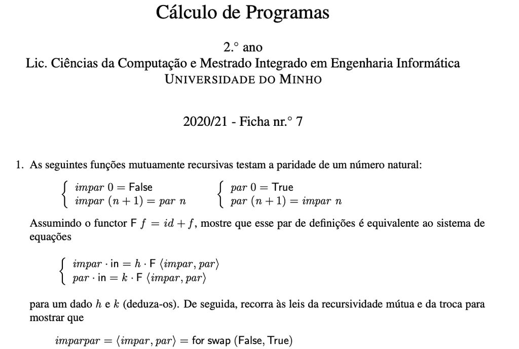

### Resolução (i)

$\def\cata#1{\mathopen{(\!|}#1\mathclose{|\!)}}\def\kons#1{\underline{#1}}$ Sabendo que $in = [\kons{0},succ]$ temos:

$impar \ . in = h . \mathbb{F} <impar, par>$

$par \ . in = k . \mathbb{F} <impar, par>$

{ def. in; fusão-$+$; $\mathbb{F} \ f = id + f$ }

$[impar \ . \kons{0}, impar . succ] = h . (id + <impar, par>)$

$[par \ . \kons{0}, par . succ] = k . (id + <impar, par>)$

{ h = [h1,h2]; k = [k1,k2] }

$[impar \ . \kons{0}, impar . succ] = [h1,h2] . (id + <impar, par>)$

$[par \ . \kons{0}, par . succ] = [k1,k2] . (id + <impar, par>)$

{ absorção-$+$ }

$[impar \ . \kons{0}, impar . succ] = [h1 . id, h2 . <impar, par>]$

$[par \ . \kons{0}, par . succ] = [k1 . id, k2 . <impar, par>]$

{ natural-id; eq-$+$ }

$impar \ . \kons{0} = h1$

$impar . succ = h2 . <impar, par>$

$par \ . \kons{0} = k1$

$par . succ = k2 . <impar, par>$

Facilmente se verifica que a equivalência é assegurada fazendo:

$h1 = \kons{False}; h2 = \pi_2$

$k1 = \kons{True}; k2 = \pi_1$

Temos então:

$impar \ 0 = False$

$impar \ (n + 1) = \pi_2 \ (impar \ n, par \ n)$

$par \ 0 = True$

$par \ (n + 1) = \pi_1 \ (impar \ n, par \ n)$

{ def-proj }

$impar \ 0 = False$

$impar \ (n + 1) = par \ n$

$par \ 0 = True$

$par \ (n + 1) = impar \ n$

### Resolução (ii)

$\def\cata#1{\mathopen{(\!|}#1\mathclose{|\!)}}\def\kons#1{\underline{#1}}$ Sabendo que $for \ b \ i = \cata{[\kons{i}, b]}$, mostrar que

$<impar, par> = for \ swap \ (False, True)$

é equivalente a mostrar que

$<impar, par> = \cata{[\kons{(False,True)}, swap]}$

{ **swap = $<\pi_2,\pi_1>$** ; $\kons{(False,True)} = <\kons{False},\kons{True}>$ }

$\equiv \ <impar, par> = \cata{[<\kons{False}, \kons{True}>, <\pi_2,\pi_1>]}$

{ **lei da troca** }

$\equiv \ <impar, par> = \cata{ <[\kons{False},\pi_2], [\kons{True}, \pi_1]> }$

{ **Fokkinga** }

$impar . in = [\kons{False},\pi_2] . \mathbb{F} <impar, par>$

$par . in = [\kons{True}, \pi_1] . \mathbb{F} <impar, par>$

{ **def. in; fusão-$+$; $\mathbb{F} \ f = id + f$** }

$[impar \ . \kons{0}, impar . succ] = [\kons{False},\pi_2] . (id + <impar, par>)$

$[par \ . \kons{0}, par . succ] = [\kons{True}, \pi_1] . (id + <impar, par>)$

{ **absorção-$+$** }

$[impar \ . \kons{0}, impar . succ] = [\kons{False} . id,\pi_2 . <impar, par>]$

$[par \ . \kons{0}, par . succ] = [\kons{True} . id, \pi_1 . <impar, par>]$

{ **natural-id; cancelamento-$\times$** }

$[impar \ . \kons{0}, impar . succ] = [\kons{False}, par]$

$[par \ . \kons{0}, par . succ] = [\kons{True}, impar]$

{ **eq-$+$** }

$impar \ . \kons{0} = \kons{False}$

$impar . succ = par$

$par \ . \kons{0} = \kons{True}$

$par . succ = impar$

{ **pointwise; natural-const; def-comp; def. succ** }

$impar \ 0 = False$

$impar \ (n + 1) = par \ n$

$par \ 0 = True$

$par \ (n + 1) = impar \ n$

### Haskell

```haskell
-- loading CP libs
:opt no-lint
:opt no-show-types
:load ../src/Cp.hs
:load ../src/Nat.hs
:load ../src/List.hs
:set -XNPlusKPatterns
```

```haskell
h1 = const False
h2 = p2
k1 = const True
k2 = p1

imparpar = cataNat (split (either h1 h2) (either k1 k2))

-- type checking

:t imparpar

-- testing

imparpar 5
```

imparpar :: forall c. Integral c => c -> (Bool, Bool)

```
(True,False)
```